# Risk Factor Analysis

## Outcome Variable

**Outcome Variable:** ever_stunted

## Predictor Variables

**Intervention Variable:** exclfeed6

**Adjustment Set:**

- arm
- sex
- W_mage
- meducyrs
- feducyrs
- hhwealth_quart
- hfoodsec
- W_mhtcm
- vagbrth
- W_gagebrth
- W_birthwt
- W_birthlen
- W_nrooms
- W_nchldlt5
- month
- brthmon
- W_parity
- impfloor
- impsan
- safeh20
- delta_W_mage
- delta_meducyrs
- delta_feducyrs
- delta_hhwealth_quart
- delta_hfoodsec
- delta_W_mhtcm
- delta_vagbrth
- delta_W_gagebrth
- delta_W_birthwt
- delta_W_birthlen
- delta_W_nrooms
- delta_W_nchldlt5
- delta_month
- delta_brthmon
- delta_W_parity
- delta_impfloor
- delta_impsan
- delta_safeh20

## Stratifying Variables

The analysis was stratified on these variable(s):

- agecat
- studyid
- country

## Data Summary

| agecat | studyid | country | exclfeed6 | ever_stunted | n_cell | n |
| --- | --- | --- | --- | --- | --- | --- |
| 0-24 months (no birth st.) | ki0047075b-MAL-ED | BANGLADESH | 0 | 0 | 71 | 198 |
| 0-24 months (no birth st.) | ki0047075b-MAL-ED | BANGLADESH | 0 | 1 | 79 | 198 |
| 0-24 months (no birth st.) | ki0047075b-MAL-ED | BANGLADESH | 1 | 0 | 20 | 198 |
| 0-24 months (no birth st.) | ki0047075b-MAL-ED | BANGLADESH | 1 | 1 | 28 | 198 |
| 0-24 months (no birth st.) | ki0047075b-MAL-ED | BRAZIL | 0 | 0 | 150 | 191 |
| 0-24 months (no birth st.) | ki0047075b-MAL-ED | BRAZIL | 0 | 1 | 27 | 191 |
| 0-24 months (no birth st.) | ki0047075b-MAL-ED | BRAZIL | 1 | 0 | 13 | 191 |
| 0-24 months (no birth st.) | ki0047075b-MAL-ED | BRAZIL | 1 | 1 | 1 | 191 |
| 0-24 months (no birth st.) | ki0047075b-MAL-ED | INDIA | 0 | 0 | 86 | 194 |
| 0-24 months (no birth st.) | ki0047075b-MAL-ED | INDIA | 0 | 1 | 105 | 194 |
| 0-24 months (no birth st.) | ki0047075b-MAL-ED | INDIA | 1 | 0 | 2 | 194 |
| 0-24 months (no birth st.) | ki0047075b-MAL-ED | INDIA | 1 | 1 | 1 | 194 |
| 0-24 months (no birth st.) | ki0047075b-MAL-ED | NEPAL | 0 | 0 | 143 | 208 |
| 0-24 months (no birth st.) | ki0047075b-MAL-ED | NEPAL | 0 | 1 | 50 | 208 |
| 0-24 months (no birth st.) | ki0047075b-MAL-ED | NEPAL | 1 | 0 | 11 | 208 |
| 0-24 months (no birth st.) | ki0047075b-MAL-ED | NEPAL | 1 | 1 | 4 | 208 |
| 0-24 months (no birth st.) | ki0047075b-MAL-ED | PERU | 0 | 0 | 90 | 238 |
| 0-24 months (no birth st.) | ki0047075b-MAL-ED | PERU | 0 | 1 | 139 | 238 |
| 0-24 months (no birth st.) | ki0047075b-MAL-ED | PERU | 1 | 0 | 2 | 238 |
| 0-24 months (no birth st.) | ki0047075b-MAL-ED | PERU | 1 | 1 | 7 | 238 |
| 0-24 months (no birth st.) | ki0047075b-MAL-ED | SOUTH AFRICA | 0 | 0 | 96 | 222 |
| 0-24 months (no birth st.) | ki0047075b-MAL-ED | SOUTH AFRICA | 0 | 1 | 126 | 222 |
| 0-24 months (no birth st.) | ki0047075b-MAL-ED | SOUTH AFRICA | 1 | 0 | 0 | 222 |
| 0-24 months (no birth st.) | ki0047075b-MAL-ED | SOUTH AFRICA | 1 | 1 | 0 | 222 |
| 0-24 months (no birth st.) | ki0047075b-MAL-ED | TANZANIA, UNITED REPUBLIC OF | 0 | 0 | 35 | 210 |
| 0-24 months (no birth st.) | ki0047075b-MAL-ED | TANZANIA, UNITED REPUBLIC OF | 0 | 1 | 174 | 210 |
| 0-24 months (no birth st.) | ki0047075b-MAL-ED | TANZANIA, UNITED REPUBLIC OF | 1 | 0 | 0 | 210 |
| 0-24 months (no birth st.) | ki0047075b-MAL-ED | TANZANIA, UNITED REPUBLIC OF | 1 | 1 | 1 | 210 |
| 0-24 months (no birth st.) | ki1000108-CMC-V-BCS-2002 | INDIA | 0 | 0 | 0 | 14 |
| 0-24 months (no birth st.) | ki1000108-CMC-V-BCS-2002 | INDIA | 0 | 1 | 0 | 14 |

[output cut: 186 more lines]

The following strata were considered:

- agecat: 0-24 months (no birth st.), studyid: ki0047075b-MAL-ED, country: BANGLADESH
- agecat: 0-24 months (no birth st.), studyid: ki0047075b-MAL-ED, country: BRAZIL
- agecat: 0-24 months (no birth st.), studyid: ki0047075b-MAL-ED, country: INDIA
- agecat: 0-24 months (no birth st.), studyid: ki0047075b-MAL-ED, country: NEPAL
- agecat: 0-24 months (no birth st.), studyid: ki0047075b-MAL-ED, country: PERU
- agecat: 0-24 months (no birth st.), studyid: ki0047075b-MAL-ED, country: SOUTH AFRICA
- agecat: 0-24 months (no birth st.), studyid: ki0047075b-MAL-ED, country: TANZANIA, UNITED REPUBLIC OF
- agecat: 0-24 months (no birth st.), studyid: ki1000108-CMC-V-BCS-2002, country: INDIA
- agecat: 0-24 months (no birth st.), studyid: ki1000108-IRC, country: INDIA
- agecat: 0-24 months (no birth st.), studyid: ki1000109-EE, country: PAKISTAN
- agecat: 0-24 months (no birth st.), studyid: ki1000304b-SAS-CompFeed, country: INDIA
- agecat: 0-24 months (no birth st.), studyid: ki1000304b-SAS-FoodSuppl, country: INDIA
- agecat: 0-24 months (no birth st.), studyid: ki1017093b-PROVIDE, country: BANGLADESH
- agecat: 0-24 months (no birth st.), studyid: ki1101329-Keneba, country: GAMBIA
- agecat: 0-24 months (no birth st.), studyid: ki1113344-GMS-Nepal, country: NEPAL
- agecat: 0-24 months (no birth st.), studyid: ki1148112-LCNI-5, country: MALAWI
- agecat: 0-24 months (no birth st.), studyid: kiGH5241-JiVitA-3, country: BANGLADESH
- agecat: 0-24 months (no birth st.), studyid: kiGH5241-JiVitA-4, country: BANGLADESH
- agecat: 0-6 months (no birth st.), studyid: ki0047075b-MAL-ED, country: BANGLADESH
- agecat: 0-6 months (no birth st.), studyid: ki0047075b-MAL-ED, country: BRAZIL
- agecat: 0-6 months (no birth st.), studyid: ki0047075b-MAL-ED, country: INDIA
- agecat: 0-6 months (no birth st.), studyid: ki0047075b-MAL-ED, country: NEPAL
- agecat: 0-6 months (no birth st.), studyid: ki0047075b-MAL-ED, country: PERU
- agecat: 0-6 months (no birth st.), studyid: ki0047075b-MAL-ED, country: SOUTH AFRICA
- agecat: 0-6 months (no birth st.), studyid: ki0047075b-MAL-ED, country: TANZANIA, UNITED REPUBLIC OF
- agecat: 0-6 months (no birth st.), studyid: ki1000108-CMC-V-BCS-2002, country: INDIA
- agecat: 0-6 months (no birth st.), studyid: ki1000108-IRC, country: INDIA
- agecat: 0-6 months (no birth st.), studyid: ki1000109-EE, country: PAKISTAN
- agecat: 0-6 months (no birth st.), studyid: ki1000304b-SAS-CompFeed, country: INDIA
- agecat: 0-6 months (no birth st.), studyid: ki1000304b-SAS-FoodSuppl, country: INDIA
- agecat: 0-6 months (no birth st.), studyid: ki1017093b-PROVIDE, country: BANGLADESH
- agecat: 0-6 months (no birth st.), studyid: ki1101329-Keneba, country: GAMBIA
- agecat: 0-6 months (no birth st.), studyid: ki1113344-GMS-Nepal, country: NEPAL
- agecat: 0-6 months (no birth st.), studyid: ki1148112-LCNI-5, country: MALAWI
- agecat: 0-6 months (no birth st.), studyid: kiGH5241-JiVitA-3, country: BANGLADESH
- agecat: 0-6 months (no birth st.), studyid: kiGH5241-JiVitA-4, country: BANGLADESH
- agecat: 6-24 months, studyid: ki0047075b-MAL-ED, country: BANGLADESH
- agecat: 6-24 months, studyid: ki0047075b-MAL-ED, country: BRAZIL
- agecat: 6-24 months, studyid: ki0047075b-MAL-ED, country: INDIA
- agecat: 6-24 months, studyid: ki0047075b-MAL-ED, country: NEPAL
- agecat: 6-24 months, studyid: ki0047075b-MAL-ED, country: PERU
- agecat: 6-24 months, studyid: ki0047075b-MAL-ED, country: SOUTH AFRICA
- agecat: 6-24 months, studyid: ki0047075b-MAL-ED, country: TANZANIA, UNITED REPUBLIC OF
- agecat: 6-24 months, studyid: ki1000108-CMC-V-BCS-2002, country: INDIA
- agecat: 6-24 months, studyid: ki1000108-IRC, country: INDIA
- agecat: 6-24 months, studyid: ki1000109-EE, country: PAKISTAN
- agecat: 6-24 months, studyid: ki1000304b-SAS-CompFeed, country: INDIA
- agecat: 6-24 months, studyid: ki1000304b-SAS-FoodSuppl, country: INDIA
- agecat: 6-24 months, studyid: ki1017093b-PROVIDE, country: BANGLADESH
- agecat: 6-24 months, studyid: ki1101329-Keneba, country: GAMBIA
- agecat: 6-24 months, studyid: ki1113344-GMS-Nepal, country: NEPAL
- agecat: 6-24 months, studyid: ki1148112-LCNI-5, country: MALAWI
- agecat: 6-24 months, studyid: kiGH5241-JiVitA-3, country: BANGLADESH
- agecat: 6-24 months, studyid: kiGH5241-JiVitA-4, country: BANGLADESH

### Dropped Strata

Some strata were dropped due to rare outcomes:

- agecat: 0-24 months (no birth st.), studyid: ki0047075b-MAL-ED, country: BRAZIL
- agecat: 0-24 months (no birth st.), studyid: ki0047075b-MAL-ED, country: INDIA
- agecat: 0-24 months (no birth st.), studyid: ki0047075b-MAL-ED, country: NEPAL
- agecat: 0-24 months (no birth st.), studyid: ki0047075b-MAL-ED, country: PERU
- agecat: 0-24 months (no birth st.), studyid: ki0047075b-MAL-ED, country: SOUTH AFRICA
- agecat: 0-24 months (no birth st.), studyid: ki0047075b-MAL-ED, country: TANZANIA, UNITED REPUBLIC OF
- agecat: 0-24 months (no birth st.), studyid: ki1000108-CMC-V-BCS-2002, country: INDIA
- agecat: 0-24 months (no birth st.), studyid: ki1000108-IRC, country: INDIA
- agecat: 0-24 months (no birth st.), studyid: ki1000304b-SAS-FoodSuppl, country: INDIA
- agecat: 0-6 months (no birth st.), studyid: ki0047075b-MAL-ED, country: BRAZIL
- agecat: 0-6 months (no birth st.), studyid: ki0047075b-MAL-ED, country: INDIA
- agecat: 0-6 months (no birth st.), studyid: ki0047075b-MAL-ED, country: NEPAL
- agecat: 0-6 months (no birth st.), studyid: ki0047075b-MAL-ED, country: PERU
- agecat: 0-6 months (no birth st.), studyid: ki0047075b-MAL-ED, country: SOUTH AFRICA
- agecat: 0-6 months (no birth st.), studyid: ki0047075b-MAL-ED, country: TANZANIA, UNITED REPUBLIC OF
- agecat: 0-6 months (no birth st.), studyid: ki1000108-CMC-V-BCS-2002, country: INDIA
- agecat: 0-6 months (no birth st.), studyid: ki1000108-IRC, country: INDIA
- agecat: 0-6 months (no birth st.), studyid: ki1000304b-SAS-FoodSuppl, country: INDIA
- agecat: 0-6 months (no birth st.), studyid: ki1148112-LCNI-5, country: MALAWI
- agecat: 6-24 months, studyid: ki0047075b-MAL-ED, country: BRAZIL
- agecat: 6-24 months, studyid: ki0047075b-MAL-ED, country: INDIA
- agecat: 6-24 months, studyid: ki0047075b-MAL-ED, country: NEPAL
- agecat: 6-24 months, studyid: ki0047075b-MAL-ED, country: PERU
- agecat: 6-24 months, studyid: ki0047075b-MAL-ED, country: SOUTH AFRICA
- agecat: 6-24 months, studyid: ki0047075b-MAL-ED, country: TANZANIA, UNITED REPUBLIC OF
- agecat: 6-24 months, studyid: ki1000108-CMC-V-BCS-2002, country: INDIA
- agecat: 6-24 months, studyid: ki1000108-IRC, country: INDIA
- agecat: 6-24 months, studyid: ki1000304b-SAS-CompFeed, country: INDIA
- agecat: 6-24 months, studyid: ki1000304b-SAS-FoodSuppl, country: INDIA

## Methods Detail

We’re interested in the causal parameters $E[Y_a]$ for all values of $a \in \mathcal{A}$. These parameters represent the mean outcome if, possibly contrary to fact, we intervened to set all units to have $A=a$. Under the randomization and positivity assumptions, these are identified by the statistical parameters $\psi_a=E_W[E_{Y|A,W}(Y|A=a,W)]$. In addition, we’re interested in the mean of $Y$, $E[Y]$ under no intervention (the observed mean). We will estimate these parameters by using SuperLearner to fit the relevant likelihood factors – $E_{Y|A,W}(Y|A=a,W)$ and $p(A=a|W)$, and then updating our likelihood fit using a joint TMLE.

For unadjusted analyses ($W=\{\}$), initial likelihoods were estimated using Lrnr_glm to estimate the simple $E(Y|A)$ and Lrnr_mean to estimate $p(A)$. For adjusted analyses, a small library containing Lrnr_glmnet, Lrnr_xgboost, and Lrnr_mean was used.

Having estimated these parameters, we will then use the delta method to estimate relative risks and attributable risks relative to a prespecified baseline level of $A$.

# Results Detail

## Results Plots

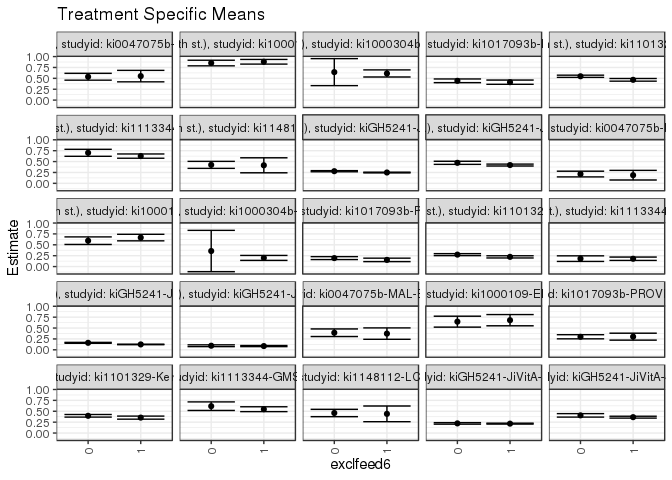

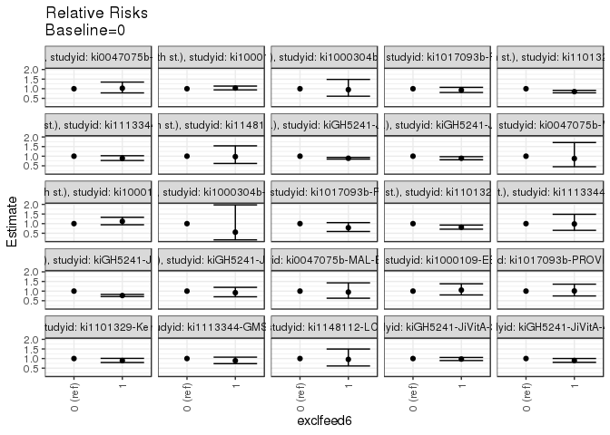

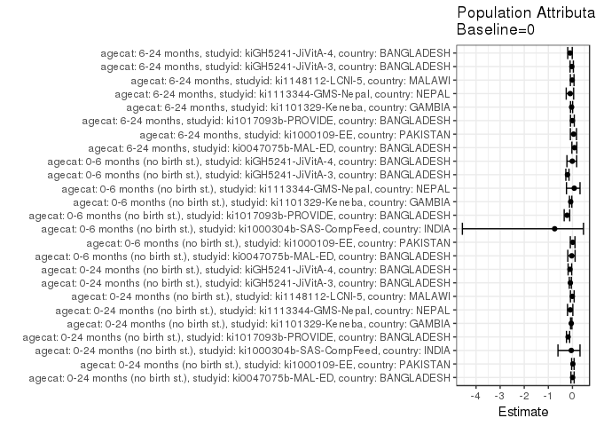

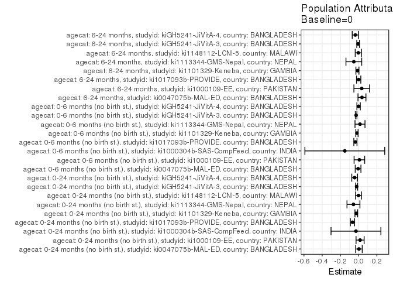

## Results Table

### Parameter: TSM

| agecat | studyid | country | intervention_level | baseline_level | estimate | ci_lower | ci_upper |
| --- | --- | --- | --- | --- | --- | --- | --- |
| 0-24 months (no birth st.) | ki0047075b-MAL-ED | BANGLADESH | 0 | NA | 0.5368924 | 0.4585787 | 0.6152060 |
| 0-24 months (no birth st.) | ki0047075b-MAL-ED | BANGLADESH | 1 | NA | 0.5514836 | 0.4193933 | 0.6835740 |
| 0-24 months (no birth st.) | ki1000109-EE | PAKISTAN | 0 | NA | 0.8516501 | 0.7877417 | 0.9155585 |
| 0-24 months (no birth st.) | ki1000109-EE | PAKISTAN | 1 | NA | 0.8809557 | 0.8273140 | 0.9345974 |
| 0-24 months (no birth st.) | ki1000304b-SAS-CompFeed | INDIA | 0 | NA | 0.6428571 | 0.3329177 | 0.9527966 |
| 0-24 months (no birth st.) | ki1000304b-SAS-CompFeed | INDIA | 1 | NA | 0.6121795 | 0.5306906 | 0.6936683 |
| 0-24 months (no birth st.) | ki1017093b-PROVIDE | BANGLADESH | 0 | NA | 0.4430466 | 0.4006767 | 0.4854165 |
| 0-24 months (no birth st.) | ki1017093b-PROVIDE | BANGLADESH | 1 | NA | 0.4118812 | 0.3633947 | 0.4603676 |
| 0-24 months (no birth st.) | ki1101329-Keneba | GAMBIA | 0 | NA | 0.5478078 | 0.5223300 | 0.5732856 |
| 0-24 months (no birth st.) | ki1101329-Keneba | GAMBIA | 1 | NA | 0.4657765 | 0.4353121 | 0.4962408 |
| 0-24 months (no birth st.) | ki1113344-GMS-Nepal | NEPAL | 0 | NA | 0.7016129 | 0.6209990 | 0.7822268 |
| 0-24 months (no birth st.) | ki1113344-GMS-Nepal | NEPAL | 1 | NA | 0.6259947 | 0.5771030 | 0.6748864 |
| 0-24 months (no birth st.) | ki1148112-LCNI-5 | MALAWI | 0 | NA | 0.4245326 | 0.3440776 | 0.5049877 |
| 0-24 months (no birth st.) | ki1148112-LCNI-5 | MALAWI | 1 | NA | 0.4147245 | 0.2424255 | 0.5870234 |
| 0-24 months (no birth st.) | kiGH5241-JiVitA-3 | BANGLADESH | 0 | NA | 0.2792058 | 0.2661092 | 0.2923024 |
| 0-24 months (no birth st.) | kiGH5241-JiVitA-3 | BANGLADESH | 1 | NA | 0.2489370 | 0.2405863 | 0.2572877 |
| 0-24 months (no birth st.) | kiGH5241-JiVitA-4 | BANGLADESH | 0 | NA | 0.4713473 | 0.4355695 | 0.5071250 |
| 0-24 months (no birth st.) | kiGH5241-JiVitA-4 | BANGLADESH | 1 | NA | 0.4201246 | 0.3982953 | 0.4419539 |
| 0-6 months (no birth st.) | ki0047075b-MAL-ED | BANGLADESH | 0 | NA | 0.2133333 | 0.1476089 | 0.2790577 |
| 0-6 months (no birth st.) | ki0047075b-MAL-ED | BANGLADESH | 1 | NA | 0.1875000 | 0.0768021 | 0.2981979 |
| 0-6 months (no birth st.) | ki1000109-EE | PAKISTAN | 0 | NA | 0.5943832 | 0.5076631 | 0.6811033 |
| 0-6 months (no birth st.) | ki1000109-EE | PAKISTAN | 1 | NA | 0.6660700 | 0.5912367 | 0.7409033 |
| 0-6 months (no birth st.) | ki1000304b-SAS-CompFeed | INDIA | 0 | NA | 0.3571429 | -0.1170496 | 0.8313354 |
| 0-6 months (no birth st.) | ki1000304b-SAS-CompFeed | INDIA | 1 | NA | 0.1987179 | 0.1419130 | 0.2555229 |
| 0-6 months (no birth st.) | ki1017093b-PROVIDE | BANGLADESH | 0 | NA | 0.1947274 | 0.1607065 | 0.2287483 |
| 0-6 months (no birth st.) | ki1017093b-PROVIDE | BANGLADESH | 1 | NA | 0.1534746 | 0.1140602 | 0.1928890 |
| 0-6 months (no birth st.) | ki1101329-Keneba | GAMBIA | 0 | NA | 0.2748063 | 0.2519824 | 0.2976302 |
| 0-6 months (no birth st.) | ki1101329-Keneba | GAMBIA | 1 | NA | 0.2232353 | 0.1978427 | 0.2486279 |
| 0-6 months (no birth st.) | ki1113344-GMS-Nepal | NEPAL | 0 | NA | 0.1827970 | 0.1185551 | 0.2470389 |
| 0-6 months (no birth st.) | ki1113344-GMS-Nepal | NEPAL | 1 | NA | 0.1799277 | 0.1412641 | 0.2185913 |
| 0-6 months (no birth st.) | kiGH5241-JiVitA-3 | BANGLADESH | 0 | NA | 0.1607352 | 0.1503645 | 0.1711059 |
| 0-6 months (no birth st.) | kiGH5241-JiVitA-3 | BANGLADESH | 1 | NA | 0.1237762 | 0.1178053 | 0.1297470 |
| 0-6 months (no birth st.) | kiGH5241-JiVitA-4 | BANGLADESH | 0 | NA | 0.0934799 | 0.0728210 | 0.1141387 |
| 0-6 months (no birth st.) | kiGH5241-JiVitA-4 | BANGLADESH | 1 | NA | 0.0856982 | 0.0724703 | 0.0989260 |
| 6-24 months | ki0047075b-MAL-ED | BANGLADESH | 0 | NA | 0.3921994 | 0.3050672 | 0.4793315 |
| 6-24 months | ki0047075b-MAL-ED | BANGLADESH | 1 | NA | 0.3720529 | 0.2410423 | 0.5030634 |
| 6-24 months | ki1000109-EE | PAKISTAN | 0 | NA | 0.6465293 | 0.5209603 | 0.7720982 |
| 6-24 months | ki1000109-EE | PAKISTAN | 1 | NA | 0.6802538 | 0.5515330 | 0.8089746 |
| 6-24 months | ki1017093b-PROVIDE | BANGLADESH | 0 | NA | 0.2996084 | 0.2519625 | 0.3472544 |
| 6-24 months | ki1017093b-PROVIDE | BANGLADESH | 1 | NA | 0.3019454 | 0.2224143 | 0.3814765 |
| 6-24 months | ki1101329-Keneba | GAMBIA | 0 | NA | 0.3957122 | 0.3656586 | 0.4257658 |
| 6-24 months | ki1101329-Keneba | GAMBIA | 1 | NA | 0.3542789 | 0.3189605 | 0.3895973 |
| 6-24 months | ki1113344-GMS-Nepal | NEPAL | 0 | NA | 0.6169003 | 0.5186194 | 0.7151812 |
| 6-24 months | ki1113344-GMS-Nepal | NEPAL | 1 | NA | 0.5478895 | 0.4917945 | 0.6039845 |
| 6-24 months | ki1148112-LCNI-5 | MALAWI | 0 | NA | 0.4601748 | 0.3758364 | 0.5445133 |
| 6-24 months | ki1148112-LCNI-5 | MALAWI | 1 | NA | 0.4405930 | 0.2602303 | 0.6209557 |
| 6-24 months | kiGH5241-JiVitA-3 | BANGLADESH | 0 | NA | 0.2217363 | 0.2047063 | 0.2387663 |
| 6-24 months | kiGH5241-JiVitA-3 | BANGLADESH | 1 | NA | 0.2158888 | 0.2058176 | 0.2259599 |
| 6-24 months | kiGH5241-JiVitA-4 | BANGLADESH | 0 | NA | 0.4061006 | 0.3666391 | 0.4455622 |
| 6-24 months | kiGH5241-JiVitA-4 | BANGLADESH | 1 | NA | 0.3646707 | 0.3427889 | 0.3865524 |

### Parameter: E(Y)

| agecat | studyid | country | intervention_level | baseline_level | estimate | ci_lower | ci_upper |
| --- | --- | --- | --- | --- | --- | --- | --- |
| 0-24 months (no birth st.) | ki0047075b-MAL-ED | BANGLADESH | NA | NA | 0.5404040 | 0.4708116 | 0.6099965 |
| 0-24 months (no birth st.) | ki1000109-EE | PAKISTAN | NA | NA | 0.8674699 | 0.8252704 | 0.9096693 |
| 0-24 months (no birth st.) | ki1000304b-SAS-CompFeed | INDIA | NA | NA | 0.6134969 | 0.5286303 | 0.6983636 |
| 0-24 months (no birth st.) | ki1017093b-PROVIDE | BANGLADESH | NA | NA | 0.3753943 | 0.3376725 | 0.4131162 |
| 0-24 months (no birth st.) | ki1101329-Keneba | GAMBIA | NA | NA | 0.5219970 | 0.5002246 | 0.5437695 |
| 0-24 months (no birth st.) | ki1113344-GMS-Nepal | NEPAL | NA | NA | 0.6447106 | 0.6027601 | 0.6866610 |
| 0-24 months (no birth st.) | ki1148112-LCNI-5 | MALAWI | NA | NA | 0.4228571 | 0.3494545 | 0.4962598 |
| 0-24 months (no birth st.) | kiGH5241-JiVitA-3 | BANGLADESH | NA | NA | 0.2568529 | 0.2489241 | 0.2647817 |
| 0-24 months (no birth st.) | kiGH5241-JiVitA-4 | BANGLADESH | NA | NA | 0.4273377 | 0.4072583 | 0.4474171 |
| 0-6 months (no birth st.) | ki0047075b-MAL-ED | BANGLADESH | NA | NA | 0.2070707 | 0.1504870 | 0.2636544 |
| 0-6 months (no birth st.) | ki1000109-EE | PAKISTAN | NA | NA | 0.6024096 | 0.5415000 | 0.6633193 |
| 0-6 months (no birth st.) | ki1000304b-SAS-CompFeed | INDIA | NA | NA | 0.2055215 | 0.1385538 | 0.2724891 |
| 0-6 months (no birth st.) | ki1017093b-PROVIDE | BANGLADESH | NA | NA | 0.1593060 | 0.1307970 | 0.1878149 |
| 0-6 months (no birth st.) | ki1101329-Keneba | GAMBIA | NA | NA | 0.2560554 | 0.2370317 | 0.2750791 |
| 0-6 months (no birth st.) | ki1113344-GMS-Nepal | NEPAL | NA | NA | 0.1976048 | 0.1627023 | 0.2325072 |
| 0-6 months (no birth st.) | kiGH5241-JiVitA-3 | BANGLADESH | NA | NA | 0.1331973 | 0.1275046 | 0.1388899 |
| 0-6 months (no birth st.) | kiGH5241-JiVitA-4 | BANGLADESH | NA | NA | 0.0929124 | 0.0809295 | 0.1048954 |
| 6-24 months | ki0047075b-MAL-ED | BANGLADESH | NA | NA | 0.4285714 | 0.3501572 | 0.5069857 |
| 6-24 months | ki1000109-EE | PAKISTAN | NA | NA | 0.6804124 | 0.5871313 | 0.7736934 |
| 6-24 months | ki1017093b-PROVIDE | BANGLADESH | NA | NA | 0.2997812 | 0.2577294 | 0.3418330 |
| 6-24 months | ki1101329-Keneba | GAMBIA | NA | NA | 0.3823738 | 0.3569722 | 0.4077755 |
| 6-24 months | ki1113344-GMS-Nepal | NEPAL | NA | NA | 0.5642317 | 0.5153938 | 0.6130696 |
| 6-24 months | ki1148112-LCNI-5 | MALAWI | NA | NA | 0.4567901 | 0.3798457 | 0.5337346 |
| 6-24 months | kiGH5241-JiVitA-3 | BANGLADESH | NA | NA | 0.2160008 | 0.2065441 | 0.2254575 |
| 6-24 months | kiGH5241-JiVitA-4 | BANGLADESH | NA | NA | 0.3699441 | 0.3495174 | 0.3903708 |

### Parameter: RR

| agecat | studyid | country | intervention_level | baseline_level | estimate | ci_lower | ci_upper |
| --- | --- | --- | --- | --- | --- | --- | --- |
| 0-24 months (no birth st.) | ki0047075b-MAL-ED | BANGLADESH | 0 | 0 | 1.0000000 | 1.0000000 | 1.0000000 |
| 0-24 months (no birth st.) | ki0047075b-MAL-ED | BANGLADESH | 1 | 0 | 1.0271773 | 0.7837142 | 1.3462729 |
| 0-24 months (no birth st.) | ki1000109-EE | PAKISTAN | 0 | 0 | 1.0000000 | 1.0000000 | 1.0000000 |
| 0-24 months (no birth st.) | ki1000109-EE | PAKISTAN | 1 | 0 | 1.0344104 | 0.9405928 | 1.1375857 |
| 0-24 months (no birth st.) | ki1000304b-SAS-CompFeed | INDIA | 0 | 0 | 1.0000000 | 1.0000000 | 1.0000000 |
| 0-24 months (no birth st.) | ki1000304b-SAS-CompFeed | INDIA | 1 | 0 | 0.9522792 | 0.6108919 | 1.4844455 |
| 0-24 months (no birth st.) | ki1017093b-PROVIDE | BANGLADESH | 0 | 0 | 1.0000000 | 1.0000000 | 1.0000000 |
| 0-24 months (no birth st.) | ki1017093b-PROVIDE | BANGLADESH | 1 | 0 | 0.9296566 | 0.8067045 | 1.0713482 |
| 0-24 months (no birth st.) | ki1101329-Keneba | GAMBIA | 0 | 0 | 1.0000000 | 1.0000000 | 1.0000000 |
| 0-24 months (no birth st.) | ki1101329-Keneba | GAMBIA | 1 | 0 | 0.8502553 | 0.7882331 | 0.9171576 |
| 0-24 months (no birth st.) | ki1113344-GMS-Nepal | NEPAL | 0 | 0 | 1.0000000 | 1.0000000 | 1.0000000 |
| 0-24 months (no birth st.) | ki1113344-GMS-Nepal | NEPAL | 1 | 0 | 0.8922223 | 0.7764912 | 1.0252024 |
| 0-24 months (no birth st.) | ki1148112-LCNI-5 | MALAWI | 0 | 0 | 1.0000000 | 1.0000000 | 1.0000000 |
| 0-24 months (no birth st.) | ki1148112-LCNI-5 | MALAWI | 1 | 0 | 0.9768966 | 0.6206902 | 1.5375255 |
| 0-24 months (no birth st.) | kiGH5241-JiVitA-3 | BANGLADESH | 0 | 0 | 1.0000000 | 1.0000000 | 1.0000000 |
| 0-24 months (no birth st.) | kiGH5241-JiVitA-3 | BANGLADESH | 1 | 0 | 0.8915896 | 0.8480145 | 0.9374038 |
| 0-24 months (no birth st.) | kiGH5241-JiVitA-4 | BANGLADESH | 0 | 0 | 1.0000000 | 1.0000000 | 1.0000000 |
| 0-24 months (no birth st.) | kiGH5241-JiVitA-4 | BANGLADESH | 1 | 0 | 0.8913272 | 0.8159501 | 0.9736675 |
| 0-6 months (no birth st.) | ki0047075b-MAL-ED | BANGLADESH | 0 | 0 | 1.0000000 | 1.0000000 | 1.0000000 |
| 0-6 months (no birth st.) | ki0047075b-MAL-ED | BANGLADESH | 1 | 0 | 0.8789062 | 0.4515742 | 1.7106294 |
| 0-6 months (no birth st.) | ki1000109-EE | PAKISTAN | 0 | 0 | 1.0000000 | 1.0000000 | 1.0000000 |
| 0-6 months (no birth st.) | ki1000109-EE | PAKISTAN | 1 | 0 | 1.1206070 | 0.9424388 | 1.3324580 |
| 0-6 months (no birth st.) | ki1000304b-SAS-CompFeed | INDIA | 0 | 0 | 1.0000000 | 1.0000000 | 1.0000000 |
| 0-6 months (no birth st.) | ki1000304b-SAS-CompFeed | INDIA | 1 | 0 | 0.5564103 | 0.1567991 | 1.9744522 |
| 0-6 months (no birth st.) | ki1017093b-PROVIDE | BANGLADESH | 0 | 0 | 1.0000000 | 1.0000000 | 1.0000000 |
| 0-6 months (no birth st.) | ki1017093b-PROVIDE | BANGLADESH | 1 | 0 | 0.7881507 | 0.5903358 | 1.0522513 |
| 0-6 months (no birth st.) | ki1101329-Keneba | GAMBIA | 0 | 0 | 1.0000000 | 1.0000000 | 1.0000000 |
| 0-6 months (no birth st.) | ki1101329-Keneba | GAMBIA | 1 | 0 | 0.8123368 | 0.7117033 | 0.9271998 |
| 0-6 months (no birth st.) | ki1113344-GMS-Nepal | NEPAL | 0 | 0 | 1.0000000 | 1.0000000 | 1.0000000 |
| 0-6 months (no birth st.) | ki1113344-GMS-Nepal | NEPAL | 1 | 0 | 0.9843032 | 0.6517940 | 1.4864403 |
| 0-6 months (no birth st.) | kiGH5241-JiVitA-3 | BANGLADESH | 0 | 0 | 1.0000000 | 1.0000000 | 1.0000000 |
| 0-6 months (no birth st.) | kiGH5241-JiVitA-3 | BANGLADESH | 1 | 0 | 0.7700627 | 0.7157668 | 0.8284773 |
| 0-6 months (no birth st.) | kiGH5241-JiVitA-4 | BANGLADESH | 0 | 0 | 1.0000000 | 1.0000000 | 1.0000000 |
| 0-6 months (no birth st.) | kiGH5241-JiVitA-4 | BANGLADESH | 1 | 0 | 0.9167553 | 0.7028963 | 1.1956817 |
| 6-24 months | ki0047075b-MAL-ED | BANGLADESH | 0 | 0 | 1.0000000 | 1.0000000 | 1.0000000 |
| 6-24 months | ki0047075b-MAL-ED | BANGLADESH | 1 | 0 | 0.9486320 | 0.6295390 | 1.4294631 |
| 6-24 months | ki1000109-EE | PAKISTAN | 0 | 0 | 1.0000000 | 1.0000000 | 1.0000000 |
| 6-24 months | ki1000109-EE | PAKISTAN | 1 | 0 | 1.0521624 | 0.8020142 | 1.3803320 |
| 6-24 months | ki1017093b-PROVIDE | BANGLADESH | 0 | 0 | 1.0000000 | 1.0000000 | 1.0000000 |
| 6-24 months | ki1017093b-PROVIDE | BANGLADESH | 1 | 0 | 1.0078001 | 0.7472107 | 1.3592700 |
| 6-24 months | ki1101329-Keneba | GAMBIA | 0 | 0 | 1.0000000 | 1.0000000 | 1.0000000 |
| 6-24 months | ki1101329-Keneba | GAMBIA | 1 | 0 | 0.8952943 | 0.7942458 | 1.0091988 |
| 6-24 months | ki1113344-GMS-Nepal | NEPAL | 0 | 0 | 1.0000000 | 1.0000000 | 1.0000000 |
| 6-24 months | ki1113344-GMS-Nepal | NEPAL | 1 | 0 | 0.8881329 | 0.7349550 | 1.0732358 |
| 6-24 months | ki1148112-LCNI-5 | MALAWI | 0 | 0 | 1.0000000 | 1.0000000 | 1.0000000 |
| 6-24 months | ki1148112-LCNI-5 | MALAWI | 1 | 0 | 0.9574470 | 0.6132645 | 1.4947950 |
| 6-24 months | kiGH5241-JiVitA-3 | BANGLADESH | 0 | 0 | 1.0000000 | 1.0000000 | 1.0000000 |
| 6-24 months | kiGH5241-JiVitA-3 | BANGLADESH | 1 | 0 | 0.9736282 | 0.8967799 | 1.0570620 |
| 6-24 months | kiGH5241-JiVitA-4 | BANGLADESH | 0 | 0 | 1.0000000 | 1.0000000 | 1.0000000 |
| 6-24 months | kiGH5241-JiVitA-4 | BANGLADESH | 1 | 0 | 0.8979810 | 0.8037197 | 1.0032974 |

### Parameter: PAR

| agecat | studyid | country | intervention_level | baseline_level | estimate | ci_lower | ci_upper |
| --- | --- | --- | --- | --- | --- | --- | --- |
| 0-24 months (no birth st.) | ki0047075b-MAL-ED | BANGLADESH | 0 | NA | 0.0035117 | -0.0323903 | 0.0394137 |
| 0-24 months (no birth st.) | ki1000109-EE | PAKISTAN | 0 | NA | 0.0158198 | -0.0285510 | 0.0601906 |
| 0-24 months (no birth st.) | ki1000304b-SAS-CompFeed | INDIA | 0 | NA | -0.0293602 | -0.3028367 | 0.2441163 |
| 0-24 months (no birth st.) | ki1017093b-PROVIDE | BANGLADESH | 0 | NA | -0.0676523 | -0.0909106 | -0.0443939 |
| 0-24 months (no birth st.) | ki1101329-Keneba | GAMBIA | 0 | NA | -0.0258108 | -0.0404083 | -0.0112133 |
| 0-24 months (no birth st.) | ki1113344-GMS-Nepal | NEPAL | 0 | NA | -0.0569023 | -0.1279063 | 0.0141017 |
| 0-24 months (no birth st.) | ki1148112-LCNI-5 | MALAWI | 0 | NA | -0.0016755 | -0.0340502 | 0.0306993 |
| 0-24 months (no birth st.) | kiGH5241-JiVitA-3 | BANGLADESH | 0 | NA | -0.0223529 | -0.0331801 | -0.0115256 |
| 0-24 months (no birth st.) | kiGH5241-JiVitA-4 | BANGLADESH | 0 | NA | -0.0440096 | -0.0754086 | -0.0126106 |
| 0-6 months (no birth st.) | ki0047075b-MAL-ED | BANGLADESH | 0 | NA | -0.0062626 | -0.0375103 | 0.0249851 |
| 0-6 months (no birth st.) | ki1000109-EE | PAKISTAN | 0 | NA | 0.0080264 | -0.0500129 | 0.0660657 |
| 0-6 months (no birth st.) | ki1000304b-SAS-CompFeed | INDIA | 0 | NA | -0.1516214 | -0.5893715 | 0.2861288 |
| 0-6 months (no birth st.) | ki1017093b-PROVIDE | BANGLADESH | 0 | NA | -0.0354214 | -0.0528121 | -0.0180308 |
| 0-6 months (no birth st.) | ki1101329-Keneba | GAMBIA | 0 | NA | -0.0187509 | -0.0311504 | -0.0063515 |
| 0-6 months (no birth st.) | ki1113344-GMS-Nepal | NEPAL | 0 | NA | 0.0148078 | -0.0399162 | 0.0695318 |
| 0-6 months (no birth st.) | kiGH5241-JiVitA-3 | BANGLADESH | 0 | NA | -0.0275379 | -0.0362139 | -0.0188620 |
| 0-6 months (no birth st.) | kiGH5241-JiVitA-4 | BANGLADESH | 0 | NA | -0.0005674 | -0.0192509 | 0.0181161 |
| 6-24 months | ki0047075b-MAL-ED | BANGLADESH | 0 | NA | 0.0363721 | -0.0073206 | 0.0800647 |
| 6-24 months | ki1000109-EE | PAKISTAN | 0 | NA | 0.0338831 | -0.0520960 | 0.1198622 |
| 6-24 months | ki1017093b-PROVIDE | BANGLADESH | 0 | NA | 0.0001727 | -0.0233864 | 0.0237318 |
| 6-24 months | ki1101329-Keneba | GAMBIA | 0 | NA | -0.0133384 | -0.0301430 | 0.0034663 |
| 6-24 months | ki1113344-GMS-Nepal | NEPAL | 0 | NA | -0.0526686 | -0.1390509 | 0.0337138 |
| 6-24 months | ki1148112-LCNI-5 | MALAWI | 0 | NA | -0.0033847 | -0.0375701 | 0.0308007 |
| 6-24 months | kiGH5241-JiVitA-3 | BANGLADESH | 0 | NA | -0.0057356 | -0.0204850 | 0.0090139 |
| 6-24 months | kiGH5241-JiVitA-4 | BANGLADESH | 0 | NA | -0.0361565 | -0.0703735 | -0.0019396 |

### Parameter: PAF

| agecat | studyid | country | intervention_level | baseline_level | estimate | ci_lower | ci_upper |
| --- | --- | --- | --- | --- | --- | --- | --- |
| 0-24 months (no birth st.) | ki0047075b-MAL-ED | BANGLADESH | 0 | NA | 0.0064983 | -0.0622147 | 0.0707663 |
| 0-24 months (no birth st.) | ki1000109-EE | PAKISTAN | 0 | NA | 0.0182367 | -0.0343604 | 0.0681592 |
| 0-24 months (no birth st.) | ki1000304b-SAS-CompFeed | INDIA | 0 | NA | -0.0478571 | -0.6004468 | 0.3139387 |
| 0-24 months (no birth st.) | ki1017093b-PROVIDE | BANGLADESH | 0 | NA | -0.1802165 | -0.2483077 | -0.1158395 |
| 0-24 months (no birth st.) | ki1101329-Keneba | GAMBIA | 0 | NA | -0.0494462 | -0.0779908 | -0.0216573 |
| 0-24 months (no birth st.) | ki1113344-GMS-Nepal | NEPAL | 0 | NA | -0.0882603 | -0.2046469 | 0.0168817 |
| 0-24 months (no birth st.) | ki1148112-LCNI-5 | MALAWI | 0 | NA | -0.0039623 | -0.0835167 | 0.0697511 |
| 0-24 months (no birth st.) | kiGH5241-JiVitA-3 | BANGLADESH | 0 | NA | -0.0870260 | -0.1302353 | -0.0454685 |
| 0-24 months (no birth st.) | kiGH5241-JiVitA-4 | BANGLADESH | 0 | NA | -0.1029855 | -0.1795793 | -0.0313652 |
| 0-6 months (no birth st.) | ki0047075b-MAL-ED | BANGLADESH | 0 | NA | -0.0302439 | -0.1926381 | 0.1100380 |
| 0-6 months (no birth st.) | ki1000109-EE | PAKISTAN | 0 | NA | 0.0133239 | -0.0879853 | 0.1051996 |
| 0-6 months (no birth st.) | ki1000304b-SAS-CompFeed | INDIA | 0 | NA | -0.7377399 | -4.5662156 | 0.4574878 |
| 0-6 months (no birth st.) | ki1017093b-PROVIDE | BANGLADESH | 0 | NA | -0.2223484 | -0.3424788 | -0.1129678 |
| 0-6 months (no birth st.) | ki1101329-Keneba | GAMBIA | 0 | NA | -0.0732300 | -0.1230194 | -0.0256480 |
| 0-6 months (no birth st.) | ki1113344-GMS-Nepal | NEPAL | 0 | NA | 0.0749364 | -0.2479444 | 0.3142781 |
| 0-6 months (no birth st.) | kiGH5241-JiVitA-3 | BANGLADESH | 0 | NA | -0.2067454 | -0.2743130 | -0.1427604 |
| 0-6 months (no birth st.) | kiGH5241-JiVitA-4 | BANGLADESH | 0 | NA | -0.0061070 | -0.2288413 | 0.1762555 |
| 6-24 months | ki0047075b-MAL-ED | BANGLADESH | 0 | NA | 0.0848682 | -0.0231189 | 0.1814575 |
| 6-24 months | ki1000109-EE | PAKISTAN | 0 | NA | 0.0497979 | -0.0854048 | 0.1681592 |
| 6-24 months | ki1017093b-PROVIDE | BANGLADESH | 0 | NA | 0.0005762 | -0.0811816 | 0.0761516 |
| 6-24 months | ki1101329-Keneba | GAMBIA | 0 | NA | -0.0348830 | -0.0799104 | 0.0082669 |
| 6-24 months | ki1113344-GMS-Nepal | NEPAL | 0 | NA | -0.0933457 | -0.2581319 | 0.0498574 |
| 6-24 months | ki1148112-LCNI-5 | MALAWI | 0 | NA | -0.0074097 | -0.0851031 | 0.0647208 |
| 6-24 months | kiGH5241-JiVitA-3 | BANGLADESH | 0 | NA | -0.0265535 | -0.0972459 | 0.0395844 |
| 6-24 months | kiGH5241-JiVitA-4 | BANGLADESH | 0 | NA | -0.0977352 | -0.1945361 | -0.0087786 |